# Exercise 3 - Analysis of examiner demographics and advice networks at the USPTO

Sheida Majidi

2024-03-31

# Introduction

In this analysis, I delve into the demographics of patent examiners and their advice networks within the United States Patent and Trademark Office (USPTO).

# Data loading and preprocessing

First, I load the data and prepare it for the analysis:

```r
applications = read_csv("/Users/sheidamajidi/Desktop/Winter2024/Winter2024-2/ORGB672/Exercises/Exercise 3/app_data_starter.csv")
edges = read_csv("/Users/sheidamajidi/Desktop/Winter2024/Winter2024-2/ORGB672/Exercises/Exercise 3/edges_sample.csv")
```

# Demographic analysis

## Gender estimation

I’ll estimate the gender of examiners based on their first names to explore gender diversity.

## Race estimation

Next, I’ll estimate the racial background of the examiners using their last names.

```
## Predicting race for 2020
```

```
## Proceeding with last name predictions...
```

```
## ℹ All local files already up-to-date!
```

```
## 701 (18.4%) individuals' last names were not matched.
```

## Tenure calculation

# Workgroup analysis

# Network analysis

## Advice network creation

Now, let’s examine the advice networks to understand the interaction patterns among examiners.

```
## [1] 4212
```

## Centrality scores

Centrality scores will help us identify key influencers and collaborators in the network.

# Results and discussion

Let’s delve into the results to uncover insights about the demographics and network dynamics of USPTO examiners.

## Demographic distribution

[figure not shown]

## Network visualization

[output not shown]

[output cut: 10108 more lines]

[output not shown]

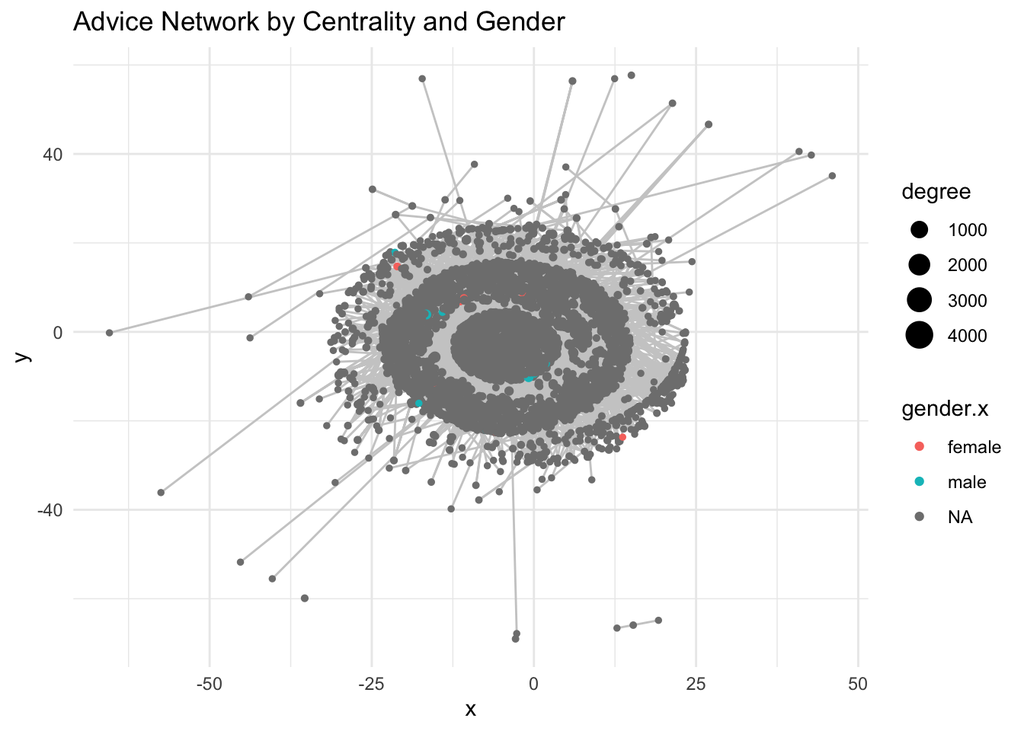

## Demographic statistics

```
## # A tibble: 3 × 2
##   gender.x   Count
##   <chr>      <int>
## 1 female    571227
## 2 male     1143391
## 3 <NA>      303859
```

```
## # A tibble: 5 × 2
##   race.x     Count
##   <chr>      <int>
## 1 Asian     591644
## 2 Hispanic   58856
## 3 black      89559
## 4 other       1891
## 5 white    1276527
```

## Network centrality measures

```
##   Average_Degree Median_Degree Average_Closeness Median_Closeness
## 1       15.62488             4         0.2310755     0.0002387205
##   Average_Betweenness Median_Betweenness
## 1            868.2317                  0
```

# Conclusion

Taking a look at the USPTO’s data, it’s clear we’ve got a vibrant mix of examiners from various racial backgrounds, with white and Asian colleagues being particularly prevalent. There’s room for growth in representation across all groups, especially among Hispanic and Black communities. The gender balance also leans more towards men, and there’s a noticeable portion of the data where gender details are missing. It would be beneficial to delve into why that’s the case and work towards a more balanced representation.

When it comes to the advice network within the organization, it’s fascinating to see how knowledge and support flow between colleagues. Many have a small, close-knit circle of contacts they interact with, but a few key individuals stand out as central nodes, forming the backbone of the network. These pivotal players are integral to the spread of information, although it’s worth noting that the overall connectivity could be improved. The majority of examiners aren’t regularly bridging communication between others, with only a select few serving as frequent connectors.

Overall, these insights highlight an opportunity to foster stronger connections across the board, encouraging a richer tapestry of interaction and collaboration. Enhancing the network and striving for greater diversity could lead to a more dynamic and inclusive environment, which I believe could greatly benefit our collective creativity and efficiency.